# My Quarto Profile Assignment

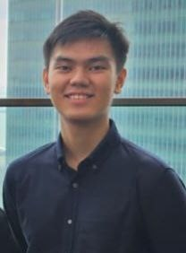

Leslie (yes i dont have last name)

Year 1 student of Applied Artificial Intelligence

Singapore Institute of Technology  
[Github](https://github.com/lleslie137/)| [Linkedin](https://www.linkedin.com/in/leslie-leslie-01bb37186/)

## 1 Work Experience

NCS  
Sep 2021 - Apr 2022  
INTERN- PRODUCT ENGINEER  
Support end to end project delivery, collaborate with customer, robot vendor, and technical supports for projects.  
- Tray return trial project Liaised with customer to help route planning and mapping of robot using robot’s software Diagnoses and troubleshoot issues during trial with robot’s software.  
- Patrol Robot trial project Modified existing robot SDK in Java to suits client’s and trial’s requirement. Setup and maintained robot server with AWS EC2 Wrote script in Python to control robot’s video streaming service Diagnoses and troubleshoot issues during trial.  
- Maintained and updated product website.  
- Active participate in team agile development cycle, facilitate the scrum team to progress as planned.  
- Manage daily scrum meeting  
- Preparation and writing meeting minutes for biweekly sprint planning and review.  
- Sorted and organized files, spreadsheets and reports.

## 2 Education

- Bachelor in Applied Artificial Intelligence  
  Singapore Institute of Technology  
  2023-Now
- Diploma in Information Technology  
  Republic Polytechnic  
  2019-2022

## 3 Achievement

- SCS SPLASH AWARDS 2021 SECOND PLACING  
  2021  
  Competed as a team of 6 and won first runner up in tertiary level of national tech innovation competition.  
  Project: Smart Carpark
- DIRECTOR’S ROLL OF HONOUR SEM1 TO SEM3  
  Oct 2019 - Oct 2020